# Practical Machine Learning Course Project

## Background

Using devices such as Jawbone Up, Nike FuelBand, and Fitbit it is now possible to collect a large amount of data about personal activity relatively inexpensively. These type of devices are part of the quantified self movement – a group of enthusiasts who take measurements about themselves regularly to improve their health, to find patterns in their behavior, or because they are tech geeks. One thing that people regularly do is quantify how much of a particular activity they do, but they rarely quantify how well they do it. In this project, your goal will be to use data from accelerometers on the belt, forearm, arm, and dumbell of 6 participants. They were asked to perform barbell lifts correctly and incorrectly in 5 different ways. More information is available from the website here: http://groupware.les.inf.puc-rio.br/har (see the section on the Weight Lifting Exercise Dataset).

## Data

The training data for this project are available here: https://d396qusza40orc.cloudfront.net/predmachlearn/pml-training.csv

The test data are available here: https://d396qusza40orc.cloudfront.net/predmachlearn/pml-testing.csv

The data for this project come from this source: http://groupware.les.inf.puc-rio.br/har.

## Data Analysis

### Set working directory

```r
setwd("/Users/mac/Dropbox/coursera/practical machine learning/project")
```

### Load libraries. Allow parallel computing.

```r
library(doMC)
registerDoMC(2)
library(caret)
library(randomForest)
```

### Read data

```r
training <- read.csv("pml-training.csv")
testing <- read.csv("pml-testing.csv")
```

### Check training and testing data

```r
dim(training)
```

```
## [1] 19622   160
```

```r
str(training)
```

```
## 'data.frame':    19622 obs. of  160 variables:
##  $ X                       : int  1 2 3 4 5 6 7 8 9 10 ...
##  $ user_name               : Factor w/ 6 levels "adelmo","carlitos",..: 2 2 2 2 2 2 2 2 2 2 ...
##  $ raw_timestamp_part_1    : int  1323084231 1323084231 1323084231 1323084232 1323084232 1323084232 1323084232 1323084232 1323084232 1323084232 ...
##  $ raw_timestamp_part_2    : int  788290 808298 820366 120339 196328 304277 368296 440390 484323 484434 ...
##  $ cvtd_timestamp          : Factor w/ 20 levels "02/12/2011 13:32",..: 9 9 9 9 9 9 9 9 9 9 ...
##  $ new_window              : Factor w/ 2 levels "no","yes": 1 1 1 1 1 1 1 1 1 1 ...
##  $ num_window              : int  11 11 11 12 12 12 12 12 12 12 ...
##  $ roll_belt               : num  1.41 1.41 1.42 1.48 1.48 1.45 1.42 1.42 1.43 1.45 ...
##  $ pitch_belt              : num  8.07 8.07 8.07 8.05 8.07 8.06 8.09 8.13 8.16 8.17 ...
##  $ yaw_belt                : num  -94.4 -94.4 -94.4 -94.4 -94.4 -94.4 -94.4 -94.4 -94.4 -94.4 ...
##  $ total_accel_belt        : int  3 3 3 3 3 3 3 3 3 3 ...
##  $ kurtosis_roll_belt      : Factor w/ 397 levels "","-0.016850",..: 1 1 1 1 1 1 1 1 1 1 ...
##  $ kurtosis_picth_belt     : Factor w/ 317 levels "","-0.021887",..: 1 1 1 1 1 1 1 1 1 1 ...
##  $ kurtosis_yaw_belt       : Factor w/ 2 levels "","#DIV/0!": 1 1 1 1 1 1 1 1 1 1 ...
```

[output cut: 86 more lines]

```r
summary(training)
```

```
##        X            user_name    raw_timestamp_part_1 raw_timestamp_part_2
##  Min.   :    1   adelmo  :3892   Min.   :1.322e+09    Min.   :   294
##  1st Qu.: 4906   carlitos:3112   1st Qu.:1.323e+09    1st Qu.:252912
##  Median : 9812   charles :3536   Median :1.323e+09    Median :496380
##  Mean   : 9812   eurico  :3070   Mean   :1.323e+09    Mean   :500656
##  3rd Qu.:14717   jeremy  :3402   3rd Qu.:1.323e+09    3rd Qu.:751891
##  Max.   :19622   pedro   :2610   Max.   :1.323e+09    Max.   :998801
##
##           cvtd_timestamp  new_window    num_window      roll_belt
##  28/11/2011 14:14: 1498   no :19216   Min.   :  1.0   Min.   :-28.90
##  05/12/2011 11:24: 1497   yes:  406   1st Qu.:222.0   1st Qu.:  1.10
##  30/11/2011 17:11: 1440               Median :424.0   Median :113.00
##  05/12/2011 11:25: 1425               Mean   :430.6   Mean   : 64.41
##  02/12/2011 14:57: 1380               3rd Qu.:644.0   3rd Qu.:123.00
##  02/12/2011 13:34: 1375               Max.   :864.0   Max.   :162.00
##  (Other)         :11007
##    pitch_belt          yaw_belt       total_accel_belt kurtosis_roll_belt
##  Min.   :-55.8000   Min.   :-180.00   Min.   : 0.00             :19216
##  1st Qu.:  1.7600   1st Qu.: -88.30   1st Qu.: 3.00    #DIV/0!  :   10
##  Median :  5.2800   Median : -13.00   Median :17.00    -1.908453:    2
##  Mean   :  0.3053   Mean   : -11.21   Mean   :11.31    -0.016850:    1
##  3rd Qu.: 14.9000   3rd Qu.:  12.90   3rd Qu.:18.00    -0.021024:    1
##  Max.   : 60.3000   Max.   : 179.00   Max.   :29.00    -0.025513:    1
##                                                        (Other)  :  391
##  kurtosis_picth_belt kurtosis_yaw_belt skewness_roll_belt
##           :19216            :19216              :19216
##  #DIV/0!  :   32     #DIV/0!:  406     #DIV/0!  :    9
##  47.000000:    4                       0.000000 :    4
##  -0.150950:    3                       0.422463 :    2
##  -0.684748:    3                       -0.003095:    1
##  -1.750749:    3                       -0.010002:    1
##  (Other)  :  361                       (Other)  :  389
##  skewness_roll_belt.1 skewness_yaw_belt max_roll_belt     max_picth_belt
##           :19216             :19216     Min.   :-94.300   Min.   : 3.00
##  #DIV/0!  :   32      #DIV/0!:  406     1st Qu.:-88.000   1st Qu.: 5.00
##  0.000000 :    4                        Median : -5.100   Median :18.00
##  -2.156553:    3                        Mean   : -6.667   Mean   :12.92
##  -3.072669:    3                        3rd Qu.: 18.500   3rd Qu.:19.00
##  -6.324555:    3                        Max.   :180.000   Max.   :30.00
##  (Other)  :  361                        NA's   :19216     NA's   :19216
```

[output cut: 313 more lines]

```
##  Min.   :-446.00   Min.   :-1280.0   Min.   :-896.0   Min.   :-973.0
##  1st Qu.:-182.00   1st Qu.: -616.0   1st Qu.:   2.0   1st Qu.: 191.0
##  Median : -39.00   Median : -378.0   Median : 591.0   Median : 511.0
##  Mean   : -55.29   Mean   : -312.6   Mean   : 380.1   Mean   : 393.6
##  3rd Qu.:  26.00   3rd Qu.:  -73.0   3rd Qu.: 737.0   3rd Qu.: 653.0
##  Max.   : 291.00   Max.   :  672.0   Max.   :1480.0   Max.   :1090.0
##
##  classe
##  A:5580
##  B:3797
##  C:3422
##  D:3216
##  E:3607
##
##
```

```r
dim(testing)
```

```
## [1]  20 160
```

```r
str(testing)
```

```
## 'data.frame':    20 obs. of  160 variables:
##  $ X                       : int  1 2 3 4 5 6 7 8 9 10 ...
##  $ user_name               : Factor w/ 6 levels "adelmo","carlitos",..: 6 5 5 1 4 5 5 5 2 3 ...
##  $ raw_timestamp_part_1    : int  1323095002 1322673067 1322673075 1322832789 1322489635 1322673149 1322673128 1322673076 1323084240 1322837822 ...
##  $ raw_timestamp_part_2    : int  868349 778725 342967 560311 814776 510661 766645 54671 916313 384285 ...
##  $ cvtd_timestamp          : Factor w/ 11 levels "02/12/2011 13:33",..: 5 10 10 1 6 11 11 10 3 2 ...
##  $ new_window              : Factor w/ 1 level "no": 1 1 1 1 1 1 1 1 1 1 ...
##  $ num_window              : int  74 431 439 194 235 504 485 440 323 664 ...
##  $ roll_belt               : num  123 1.02 0.87 125 1.35 -5.92 1.2 0.43 0.93 114 ...
##  $ pitch_belt              : num  27 4.87 1.82 -41.6 3.33 1.59 4.44 4.15 6.72 22.4 ...
##  $ yaw_belt                : num  -4.75 -88.9 -88.5 162 -88.6 -87.7 -87.3 -88.5 -93.7 -13.1 ...
##  $ total_accel_belt        : int  20 4 5 17 3 4 4 4 4 18 ...
##  $ kurtosis_roll_belt      : logi  NA NA NA NA NA NA ...
##  $ kurtosis_picth_belt     : logi  NA NA NA NA NA NA ...
##  $ kurtosis_yaw_belt       : logi  NA NA NA NA NA NA ...
```

[output cut: 86 more lines]

```r
summary(testing)
```

```
##        X            user_name raw_timestamp_part_1 raw_timestamp_part_2
##  Min.   : 1.00   adelmo  :1   Min.   :1.322e+09    Min.   : 36553
##  1st Qu.: 5.75   carlitos:3   1st Qu.:1.323e+09    1st Qu.:268655
##  Median :10.50   charles :1   Median :1.323e+09    Median :530706
##  Mean   :10.50   eurico  :4   Mean   :1.323e+09    Mean   :512167
##  3rd Qu.:15.25   jeremy  :8   3rd Qu.:1.323e+09    3rd Qu.:787738
##  Max.   :20.00   pedro   :3   Max.   :1.323e+09    Max.   :920315
##
##           cvtd_timestamp new_window   num_window      roll_belt
##  30/11/2011 17:11:4      no:20      Min.   : 48.0   Min.   : -5.9200
##  05/12/2011 11:24:3                 1st Qu.:250.0   1st Qu.:  0.9075
##  30/11/2011 17:12:3                 Median :384.5   Median :  1.1100
##  05/12/2011 14:23:2                 Mean   :379.6   Mean   : 31.3055
##  28/11/2011 14:14:2                 3rd Qu.:467.0   3rd Qu.: 32.5050
##  02/12/2011 13:33:1                 Max.   :859.0   Max.   :129.0000
##  (Other)         :5
##    pitch_belt         yaw_belt      total_accel_belt kurtosis_roll_belt
##  Min.   :-41.600   Min.   :-93.70   Min.   : 2.00    Mode:logical
##  1st Qu.:  3.013   1st Qu.:-88.62   1st Qu.: 3.00    NA's:20
##  Median :  4.655   Median :-87.85   Median : 4.00
##  Mean   :  5.824   Mean   :-59.30   Mean   : 7.55
##  3rd Qu.:  6.135   3rd Qu.:-63.50   3rd Qu.: 8.00
##  Max.   : 27.800   Max.   :162.00   Max.   :21.00
##
##  kurtosis_picth_belt kurtosis_yaw_belt skewness_roll_belt
##  Mode:logical        Mode:logical      Mode:logical
##  NA's:20             NA's:20           NA's:20
##
##
##
##
##
##  skewness_roll_belt.1 skewness_yaw_belt max_roll_belt  max_picth_belt
##  Mode:logical         Mode:logical      Mode:logical   Mode:logical
##  NA's:20              NA's:20           NA's:20        NA's:20
##
##
##
##
##
```

[output cut: 289 more lines]

```
##  Min.   :-1.2600   Min.   :-212.0   Min.   :-331.0   Min.   :-282.0
##  1st Qu.:-0.0975   1st Qu.:-114.8   1st Qu.:   8.5   1st Qu.:-199.0
##  Median : 0.2300   Median :  86.0   Median : 138.0   Median :-148.5
##  Mean   : 0.2610   Mean   :  38.8   Mean   : 125.3   Mean   : -93.7
##  3rd Qu.: 0.7625   3rd Qu.: 166.2   3rd Qu.: 268.0   3rd Qu.: -31.0
##  Max.   : 1.8000   Max.   : 232.0   Max.   : 406.0   Max.   : 179.0
##
##  magnet_forearm_x magnet_forearm_y magnet_forearm_z   problem_id
##  Min.   :-714.0   Min.   :-787.0   Min.   :-32.0    Min.   : 1.00
##  1st Qu.:-427.2   1st Qu.:-328.8   1st Qu.:275.2    1st Qu.: 5.75
##  Median :-189.5   Median : 487.0   Median :491.5    Median :10.50
##  Mean   :-159.2   Mean   : 191.8   Mean   :460.2    Mean   :10.50
##  3rd Qu.:  41.5   3rd Qu.: 720.8   3rd Qu.:661.5    3rd Qu.:15.25
##  Max.   : 532.0   Max.   : 800.0   Max.   :884.0    Max.   :20.00
##
```

### Clean Data

Check missing values.

```r
colSums(is.na(training))
```

```
##                        X                user_name     raw_timestamp_part_1
##                        0                        0                        0
##     raw_timestamp_part_2           cvtd_timestamp               new_window
##                        0                        0                        0
##               num_window                roll_belt               pitch_belt
##                        0                        0                        0
##                 yaw_belt         total_accel_belt       kurtosis_roll_belt
##                        0                        0                        0
##      kurtosis_picth_belt        kurtosis_yaw_belt       skewness_roll_belt
##                        0                        0                        0
##     skewness_roll_belt.1        skewness_yaw_belt            max_roll_belt
##                        0                        0                    19216
##           max_picth_belt             max_yaw_belt            min_roll_belt
##                    19216                        0                    19216
##           min_pitch_belt             min_yaw_belt      amplitude_roll_belt
##                    19216                        0                    19216
##     amplitude_pitch_belt       amplitude_yaw_belt     var_total_accel_belt
##                    19216                        0                    19216
##            avg_roll_belt         stddev_roll_belt            var_roll_belt
##                    19216                    19216                    19216
##           avg_pitch_belt        stddev_pitch_belt           var_pitch_belt
##                    19216                    19216                    19216
##             avg_yaw_belt          stddev_yaw_belt             var_yaw_belt
##                    19216                    19216                    19216
##             gyros_belt_x             gyros_belt_y             gyros_belt_z
##                        0                        0                        0
##             accel_belt_x             accel_belt_y             accel_belt_z
##                        0                        0                        0
##            magnet_belt_x            magnet_belt_y            magnet_belt_z
##                        0                        0                        0
##                 roll_arm                pitch_arm                  yaw_arm
##                        0                        0                        0
##          total_accel_arm            var_accel_arm             avg_roll_arm
##                        0                    19216                    19216
##          stddev_roll_arm             var_roll_arm            avg_pitch_arm
##                    19216                    19216                    19216
##         stddev_pitch_arm            var_pitch_arm              avg_yaw_arm
##                    19216                    19216                    19216
##           stddev_yaw_arm              var_yaw_arm              gyros_arm_x
##                    19216                    19216                        0
```

[output cut: 53 more lines]

```
##                        0                        0                    19216
##         avg_roll_forearm      stddev_roll_forearm         var_roll_forearm
##                    19216                    19216                    19216
##        avg_pitch_forearm     stddev_pitch_forearm        var_pitch_forearm
##                    19216                    19216                    19216
##          avg_yaw_forearm       stddev_yaw_forearm          var_yaw_forearm
##                    19216                    19216                    19216
##          gyros_forearm_x          gyros_forearm_y          gyros_forearm_z
##                        0                        0                        0
##          accel_forearm_x          accel_forearm_y          accel_forearm_z
##                        0                        0                        0
##         magnet_forearm_x         magnet_forearm_y         magnet_forearm_z
##                        0                        0                        0
##                   classe
##                        0
```

```r
colSums(is.na(testing))
```

```
##                        X                user_name     raw_timestamp_part_1
##                        0                        0                        0
##     raw_timestamp_part_2           cvtd_timestamp               new_window
##                        0                        0                        0
##               num_window                roll_belt               pitch_belt
##                        0                        0                        0
##                 yaw_belt         total_accel_belt       kurtosis_roll_belt
##                        0                        0                       20
##      kurtosis_picth_belt        kurtosis_yaw_belt       skewness_roll_belt
##                       20                       20                       20
##     skewness_roll_belt.1        skewness_yaw_belt            max_roll_belt
##                       20                       20                       20
##           max_picth_belt             max_yaw_belt            min_roll_belt
##                       20                       20                       20
##           min_pitch_belt             min_yaw_belt      amplitude_roll_belt
##                       20                       20                       20
##     amplitude_pitch_belt       amplitude_yaw_belt     var_total_accel_belt
##                       20                       20                       20
##            avg_roll_belt         stddev_roll_belt            var_roll_belt
##                       20                       20                       20
##           avg_pitch_belt        stddev_pitch_belt           var_pitch_belt
##                       20                       20                       20
##             avg_yaw_belt          stddev_yaw_belt             var_yaw_belt
##                       20                       20                       20
##             gyros_belt_x             gyros_belt_y             gyros_belt_z
##                        0                        0                        0
##             accel_belt_x             accel_belt_y             accel_belt_z
##                        0                        0                        0
##            magnet_belt_x            magnet_belt_y            magnet_belt_z
##                        0                        0                        0
##                 roll_arm                pitch_arm                  yaw_arm
##                        0                        0                        0
##          total_accel_arm            var_accel_arm             avg_roll_arm
##                        0                       20                       20
##          stddev_roll_arm             var_roll_arm            avg_pitch_arm
##                       20                       20                       20
##         stddev_pitch_arm            var_pitch_arm              avg_yaw_arm
##                       20                       20                       20
##           stddev_yaw_arm              var_yaw_arm              gyros_arm_x
##                       20                       20                        0
```

[output cut: 53 more lines]

```
##                       20                        0                       20
##         avg_roll_forearm      stddev_roll_forearm         var_roll_forearm
##                       20                       20                       20
##        avg_pitch_forearm     stddev_pitch_forearm        var_pitch_forearm
##                       20                       20                       20
##          avg_yaw_forearm       stddev_yaw_forearm          var_yaw_forearm
##                       20                       20                       20
##          gyros_forearm_x          gyros_forearm_y          gyros_forearm_z
##                        0                        0                        0
##          accel_forearm_x          accel_forearm_y          accel_forearm_z
##                        0                        0                        0
##         magnet_forearm_x         magnet_forearm_y         magnet_forearm_z
##                        0                        0                        0
##               problem_id
##                        0
```

Remove columns with less than 80% complete data in testing samples.

```r
testing_complete <- testing[colSums(is.na(testing)) < 0.2 * nrow(testing)]
```

Remove column X, cvtd_timestamp, new_window and problem_id.

```r
testing_complete <- testing_complete[,-c(1,5,6,60)]
```

Check the dimension of the final testing set.

```r
dim(testing_complete)
```

```
## [1] 20 56
```

Remove corresponding columns in training samples.

```r
training_complete <- training[colSums(is.na(testing)) < 0.2 * nrow(testing)]
```

Remove column X, cvtd_timestamp, new_window.

```r
training_complete <- training_complete[,-c(1,5,6)]
```

Check the dimension of the final training set.

```r
dim(training_complete)
```

```
## [1] 19622    57
```

### Cross-validation

Create training and validation sets from the final training set so that 70% samples are in training set and 30% samples are in validation set.

```r
set.seed(1985)
inTrain <- createDataPartition(y = training_complete$classe, p = 0.7, list = FALSE)
trainSet <- training_complete[inTrain, ]
validationSet <- training_complete[-inTrain, ]
```

### Model: Random Forest

First, I try to fit a random forest model with the default setting (number of trees to grow is 500 and and the number of variables to randomly sampled as candidates at each split is sqrt(p), where p is the number of variables in the training set) to the training data set. I set `importance = TRUE` so that the importance of variables is assessed.

```r
modFit <- randomForest(classe ~., data = trainSet, importance = TRUE, proximity = TRUE)
```

### Summary of the random forest model

```r
summary(modFit)
```

```
##                 Length    Class  Mode
## call                    5 -none- call
## type                    1 -none- character
## predicted           13737 factor numeric
## err.rate             3000 -none- numeric
## confusion              30 -none- numeric
## votes               68685 matrix numeric
## oob.times           13737 -none- numeric
## classes                 5 -none- character
## importance            392 -none- numeric
## importanceSD          336 -none- numeric
## localImportance         0 -none- NULL
## proximity       188705169 -none- numeric
## ntree                   1 -none- numeric
## mtry                    1 -none- numeric
## forest                 14 -none- list
## y                   13737 factor numeric
## test                    0 -none- NULL
## inbag                   0 -none- NULL
## terms                   3 terms  call
```

```r
print(modFit)
```

```
##
## Call:
##  randomForest(formula = classe ~ ., data = trainSet, importance = TRUE,      proximity = TRUE)
##                Type of random forest: classification
##                      Number of trees: 500
## No. of variables tried at each split: 7
##
##         OOB estimate of  error rate: 0.17%
## Confusion matrix:
##      A    B    C    D    E class.error
## A 3906    0    0    0    0 0.000000000
## B    3 2654    1    0    0 0.001504891
## C    0    5 2389    2    0 0.002921536
## D    0    0    8 2243    1 0.003996448
## E    0    0    0    3 2522 0.001188119
```

The expected out of sample error is 0.17%, which is very low!

### Assess importance of predictors

The importance of predictors can be assessed by checking the magnitude of either `MeanDecreaseAccuracy` or `MeanDecreaseGini`.

```r
round(importance(modFit),2)
```

```
##                          A     B     C     D     E MeanDecreaseAccuracy
## user_name            13.97 15.79 12.83 15.98 16.93                18.13
## raw_timestamp_part_1 51.12 55.40 58.05 62.88 40.75                73.48
## raw_timestamp_part_2  6.66  7.66  8.05  8.14  8.60                16.58
## num_window           31.17 40.03 44.79 38.80 35.39                44.59
## roll_belt            30.65 40.47 34.16 40.69 35.54                44.16
## pitch_belt           25.29 38.19 31.15 31.52 28.06                39.74
## yaw_belt             30.92 36.10 33.03 38.49 24.84                45.76
## total_accel_belt     13.09 15.45 14.50 14.01 15.37                17.23
## gyros_belt_x         12.45 14.13 16.03 11.64 13.88                18.52
## gyros_belt_y         10.01 12.93 12.75 12.80 16.37                15.74
## gyros_belt_z         18.45 23.36 21.97 21.05 21.36                26.12
## accel_belt_x         12.37 15.64 15.75 12.62 14.19                18.92
## accel_belt_y          9.79 12.04 10.89 13.79 12.62                13.73
## accel_belt_z         15.08 19.81 19.02 18.27 17.74                21.57
## magnet_belt_x        13.64 22.39 20.43 17.48 20.67                25.07
## magnet_belt_y        18.45 21.81 20.91 22.59 20.25                24.20
## magnet_belt_z        17.02 20.20 19.37 23.86 20.23                22.93
## roll_arm             17.77 25.49 21.13 24.08 18.86                27.37
## pitch_arm            15.12 18.98 15.80 17.12 15.12                20.95
## yaw_arm              18.03 20.60 19.28 22.59 17.47                23.90
## total_accel_arm       8.09 18.71 15.16 16.55 15.30                19.41
## gyros_arm_x          13.18 19.45 19.42 19.13 15.90                21.98
## gyros_arm_y          13.57 21.16 18.07 20.13 17.81                28.48
## gyros_arm_z          10.09 13.82 11.05 10.73 10.29                21.05
## accel_arm_x          14.38 15.78 15.75 17.57 13.59                17.26
## accel_arm_y          15.08 16.88 14.03 15.71 13.36                20.65
## accel_arm_z          10.40 14.25 15.59 16.74 13.13                16.37
## magnet_arm_x         14.38 14.19 15.48 15.58 13.31                16.11
## magnet_arm_y         11.40 14.59 15.72 17.56 12.09                15.39
## magnet_arm_z         15.57 19.35 17.73 16.65 16.09                23.15
## roll_dumbbell        17.62 22.24 26.17 23.12 22.17                25.56
## pitch_dumbbell       10.14 16.87 14.89 11.34 13.98                15.35
## yaw_dumbbell         13.92 22.14 19.96 18.92 19.22                23.38
## total_accel_dumbbell 16.51 19.57 18.99 20.52 19.54                22.86
## gyros_dumbbell_x     13.25 19.90 17.52 16.72 15.81                26.12
## gyros_dumbbell_y     14.29 16.99 21.52 16.21 14.73                19.23
## gyros_dumbbell_z     12.22 18.06 13.71 14.61 12.52                25.88
## accel_dumbbell_x     13.95 21.12 18.15 17.69 17.20                21.17
## accel_dumbbell_y     19.80 24.03 26.78 25.44 23.34                29.80
```

[output cut: 59 more lines]

```
## magnet_dumbbell_y              415.88
## magnet_dumbbell_z              455.66
## roll_forearm                   346.55
## pitch_forearm                  445.49
## yaw_forearm                     86.52
## total_accel_forearm             47.55
## gyros_forearm_x                 33.43
## gyros_forearm_y                 54.06
## gyros_forearm_z                 35.29
## accel_forearm_x                177.41
## accel_forearm_y                 69.19
## accel_forearm_z                120.84
## magnet_forearm_x               108.44
## magnet_forearm_y               105.57
## magnet_forearm_z               132.00
```

I also try to produce the variable importance plot to visualize which variables are important in this model.

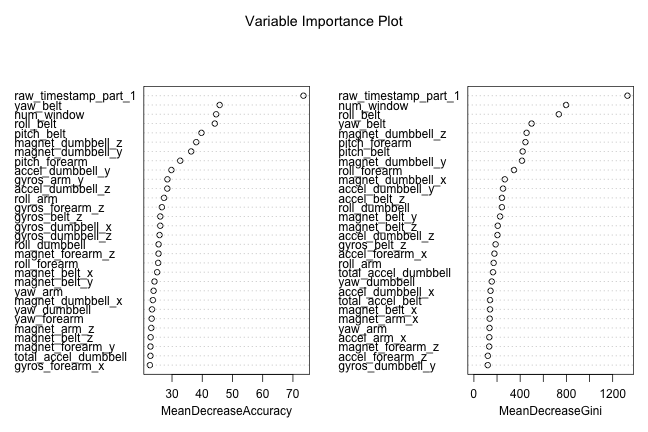

```r
varImpPlot(modFit, main = "Variable Importance Plot")
```

### Model Evaluation

Even though the random forest model itself estimates the out of sample error rates, I still evaluate this model by using the validation set.

```r
validationPred<- predict(object = modFit, newdata = validationSet[,-59])
confusionMatrix(validationPred, validationSet$classe)
```

```
## Confusion Matrix and Statistics
##
##           Reference
## Prediction    A    B    C    D    E
##          A 1674    0    0    0    0
##          B    0 1139    1    0    0
##          C    0    0 1025    3    0
##          D    0    0    0  961    2
##          E    0    0    0    0 1080
##
## Overall Statistics
##
##                Accuracy : 0.999
##                  95% CI : (0.9978, 0.9996)
##     No Information Rate : 0.2845
##     P-Value [Acc > NIR] : < 2.2e-16
##
##                   Kappa : 0.9987
##  Mcnemar's Test P-Value : NA
##
## Statistics by Class:
##
##                      Class: A Class: B Class: C Class: D Class: E
## Sensitivity            1.0000   1.0000   0.9990   0.9969   0.9982
## Specificity            1.0000   0.9998   0.9994   0.9996   1.0000
## Pos Pred Value         1.0000   0.9991   0.9971   0.9979   1.0000
## Neg Pred Value         1.0000   1.0000   0.9998   0.9994   0.9996
## Prevalence             0.2845   0.1935   0.1743   0.1638   0.1839
## Detection Rate         0.2845   0.1935   0.1742   0.1633   0.1835
## Detection Prevalence   0.2845   0.1937   0.1747   0.1636   0.1835
## Balanced Accuracy      1.0000   0.9999   0.9992   0.9982   0.9991
```

It shows that the accuracy of this random forest model on the validation set is 99.9%. The out of sample error rate is less than 1%. The sensitivity and speciicity are all very close to 100%. Therefore, I decide to use this model to predict the testing set.

### Prediction on the testing set

Finally, I apply the random forest model to predict the testing set.

```r
testingPred <- predict(object = modFit, newdata = testing_complete)
print(testingPred)
```

```
##  1  2  3  4  5  6  7  8  9 10 11 12 13 14 15 16 17 18 19 20
##  B  A  B  A  A  E  D  B  A  A  B  C  B  A  E  E  A  B  B  B
## Levels: A B C D E
```

I stored the results as a character vector and use the codes provided on the course website to create the submission text files.

```r
answers <- as.character(testingPred)
pml_write_files = function(x){
  n = length(x)
  for(i in 1:n){
    filename = paste0("problem_id_",i,".txt")
    write.table(x[i],file=filename,quote=FALSE,row.names=FALSE,col.names=FALSE)
  }
}

pml_write_files(answers)
```